# Informe práctica 2

Adam Casas

Compilado: 28 de febrero del 2021

# 1 Introducción al pseudotiempo

**El pseudotiempo es el ordenamiento basado en la similaridad de las células a lo largo de la trayectoria de un proceso de desarrollo contínuo.**

El pseudotiempo es una medida de cuánto progreso ha hecho una célula en un proceso biológico como por ejemplo la diferenciación celular. En muchos procesos biológicos, las células no progresan en perfecta sincronía. En estudios de expresión de single-cell sobre procesos tales como la diferenciación celular, las células estudiadas pueden mostrar diversos grados de desarrollo. Es decir, en una población de células capturadas exactamente a la vez, algunas células pueden estar más desarrolladas, mientras que otras pueden ni haber empezado el proceso en cuestión. Esta asincronía dificulta seriamente el estudio de la secuencia de cambios regulatorios que ocurren cuando las células transicionan de un estado a otro. Seguirle la pista a la expresión en todas las células capturadas a la vez produce un sentido muy comprimido de la cinética de un gen, y la variabilidad aparente de la expresión de ese gen será muy elevada. Al ordenar cada célula de acuerdo a su progreso a lo largo de una trayectoria aprendida, el análisis del pseudotiempo alivia los problemas derivados de la susodicha asincronía. En lugar de rastrear los cambios de la expresión génica en función del tiempo, diversas herramientas rastrean dichos cambios en función del progreso a lo largo de la trayectoria, la cual denominamos “pseudotiempo”. El pseudotiempo es una unidad abstracta de progreso: en realidad es la distancia entre una célula dada y el comienzo de la trayectoria, medida a lo largo del camino más corto. La longitud total de la trayectoria se define en términos de la cantidad total de cambios transcripcionales que sufre una célula mientras se mueve del estado inicial al final.

```r
library("SingleCellExperiment")
library("TSCAN")
library("destiny")
library("SLICER")
library("ouija")
library("scater")
library("ggplot2")
library("ggthemes")
library("ggbeeswarm")
library("corrplot")
# library("M3Drop")
# library("monocle)
```

En muchas situaciones, uno estudia un proceso en el cual las células cambian continuamente. Esto incluye, por ejemplo, muchos procesos de diferenciación que tienen lugar durante el desarrollo del organismo: tras un estímulo, las células cambian de un tipo a otro. Idealmente, nos interesaría monitorizar los niveles de expresión de una célula dada a lo largo del tiempo. Desafortunadamente, tal monitorización no es posible en scRNA-seq dado que la célula se lisa cuando el ARN se extrae.

En su lugar, debemos muestrear en múltiples puntos del tiempo y así obtener “fotografías” de los perfiles de expresión génicos. Puesto que algunas células se diferenciarán más rápido que otras, cada fotografía puede contener células en diversas etapas del desarrollo. **Usamos métodos estadísticos para ordenar las células a lo largo de una o más trayectorias las cuales representan las trayectorias del desarrollo subyacentes, este ordenamiento se conoce como “pseudotiempo”.**

En esta práctica nos centraremos en 4 herramientas para ordenar las células según su grado de desarrollo en el pseudotiempo: `TSCAN`, `SLICER`, `destiny` y `Ouija.` Para ilustrar su uso, emplearemos el dataset del desarrollo embrionario en ratón de [Deng *et al.*, 2014](https://science.sciencemag.org/content/343/6167/193). Dicho dataset cuenta con 268 células provenientes de la fase temprana del desarrollo embrional y extraídas en 10 puntos de tiempo. En este caso no hace falta alinear las células a la trayectoria del pseudotiempo dado que están ya etiquetadas con información sobre la trayectoria embrionaria. Por tanto, las etiquetas son la *ground truth* o verdad experimental sobre la cual podemos comparar el rendimiento obtenido por los susodichos métodos.

Una revisión más o menos reciente de [Cannoodt *et al.*](https://onlinelibrary.wiley.com/doi/full/10.1002/eji.201646347) publicada en 2016 nos aporta un resumen detallado de los distintos algoritmos empleados para la inferencia de trayectoria en scRNA-seq. Dicha revisión cubre:

- **Monocle** - Paquete de Bioconductor
- **TSCAN** - Paquete de Bioconductor
- **SLICER** - Paquete de R, disponible sólo a través de GitHub
- Waterfall - Paquete de R (se incluye un script en el suplemento del artículo original de Shin *et al,* 2015 y en los [archivos asociados](https://github.com/gloknar/R-Utilities/tree/master/Traduccion%20Seurat%20V2%20V3/Cosas%20accesorias%20Informe%202) a este informe)
- Mpath - Paquete de R disponible en GitHub (comprimido con formato `tar.gz`). La función está documentada, pero el workflow no, ni tiene una *vignette*.
- Wishbone - Paquete de Python
- SCUBA - Paquete de Matlab
- Wanderlust - Paquete de Matlab
- SCOUP - Programa en C++ por línea de comandos

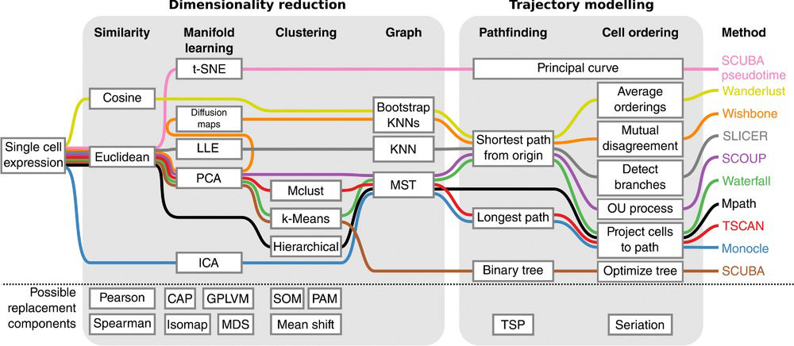

Figura 1. Descripción de los diversos métodos de inferencia de trayectoria para datos de scRNA-seq (Figura 2 de Cannoodt *et al.*, 2016).

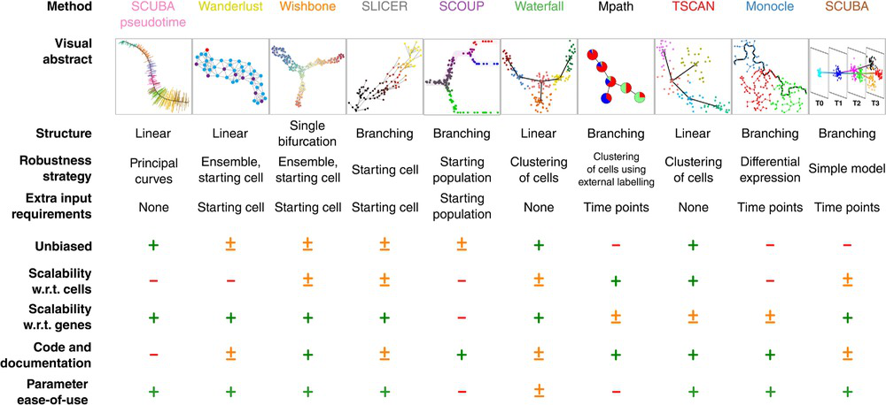

Figura 2. Caracterización de los métodos de inferencia de trayectoria para scRNA-seq (Figura 3 de Cannoodt *et al.*, 2016).

# 2 Visualización del dataset

Al igual que el dataset de Nakamura *et al.* usado en la práctica 1, el dataset de Deng *et al.* contiene células embrionarias en los primeros estadios de Carnegie, solo que en este caso las células son de ratón, y no de macaco cangrejero. El dataset de esta práctica se encuentra en el archivo `deng-reads.rds`.

```r
# Leemos los datos
deng_SCE <- readRDS(file = "./Archivos accesorios/Codigo y datos de las Practicas 1-4/data/deng-reads.rds")

# Reordenamos los niveles, ya que zigoto < 2 células < 4 células, etc...
deng_SCE$cell_type2 <- factor(deng_SCE$cell_type2,
                              levels = c("zy", "early2cell", "mid2cell", "late2cell",
                              "4cell", "8cell", "16cell", "earlyblast", "midblast",
                              "lateblast"))


# Generamos y formateamos una matriz de conteos crudos (i.e. nº de transcritos
# por gen y célula)
raw_deng <- counts(deng_SCE)

# Establecemos el nombre de las células en el objeto `cellLabels`
cellLabels <- deng_SCE$cell_type2
colnames(raw_deng) <- cellLabels
```

Tal como muestra el siguiente gráfico, el PCA muestra bastante bien la estructura de los datos y los separa correctamente en su mayoría, exceptuando aquellas células que corresponden al estadio de blastocisto (early/mid/lateblast), que están mezcladas entre sí. Se aprecia cómo las células están ordenadas en el espacio del PCA en sentido horario, desde la etapa de zigoto (zy) hasta la de blastocisto tardío (lateblast).

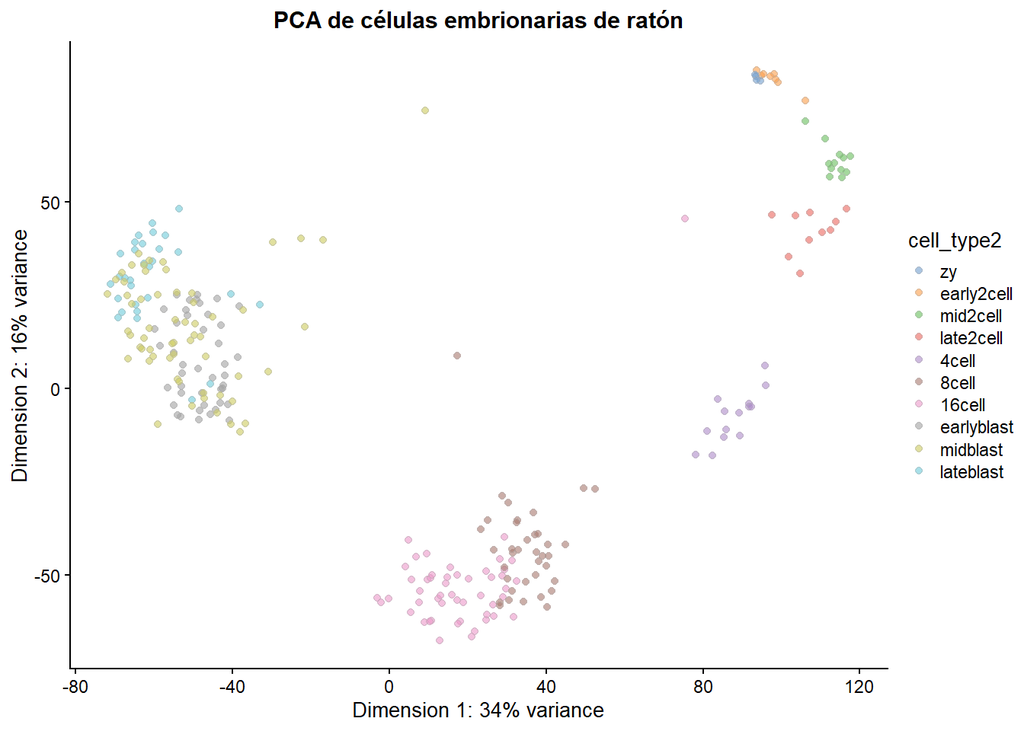

```r
set.seed(1)
# Corremos PCA en un objeto de tipo SingleCellExperiment
deng_SCE <- runPCA(deng_SCE)

# Graficamos el PCA
BiocGenerics::plotPCA(deng_SCE, colour_by = "cell_type2") +
  ggtitle("PCA de células embrionarias de ratón") +
  theme(plot.title = element_text(hjust = 0.5))
```

Aquí el PCA nos proporciona un útil punto de referencia para comprobar diversos métodos de inferencia de trayectoria. A diferencia del t-SNE y el UMAP, el PCA podría revelarnos mejor el tiempo de desarrollo, a expensas de producir un clustering peor. Un algoritmo muy sencillo de inferencia podría ser simplemente utilizar las coordenadas en el espacio del PCA de la primera componente principal.

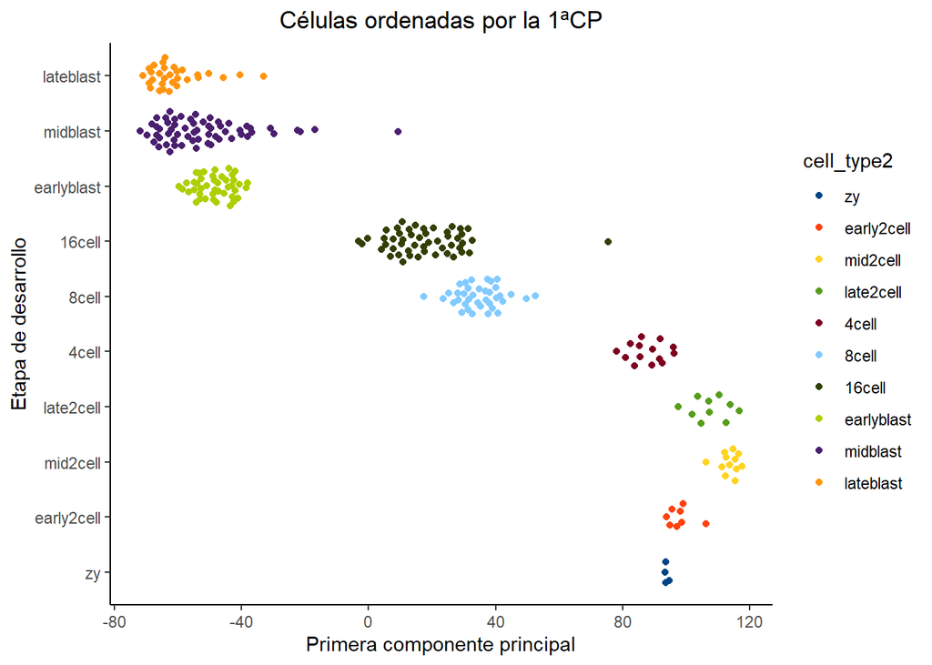

```r
deng_SCE$PC1 <- reducedDim(x = deng_SCE, type = "PCA")[,1]

# Graficamos el pseudotiempo según las coordenadas de la primera componente
# principal
ggplot(as.data.frame(colData(deng_SCE)),
       aes(x = PC1, y = cell_type2, colour = cell_type2)) +
       geom_quasirandom(groupOnX = F) + theme_classic() +
       theme(plot.title = element_text(hjust = 0.5)) +
       ggtitle("Células ordenadas por la 1ªCP") +
       xlab("Primera componente principal") + ylab("Etapa de desarrollo") +
       scale_colour_calc()
```

Aplicando dicho algoritmo básico, y tal y como muestra el gráfico anterior, vemos que a la primera dimensión le cuesta un poco diferenciar algunos tipos celulares, pero en general ordena bien las células según su estapa de desarrollo.

En las siguientes secciones veremos qué rendimiento desempeñan los algoritmos previamente citados ( *i.e.* `TSCAN` y sucedáneos).

# 3 TSCAN

`TSCAN` combina el clustering con el análisis de pseudotiempo. Primero agrupa las células usando `mclust`, el cual se basa en una mezcla de distribuciones normales. Seguidamente construye un árbol del menor tamaño posible que conecte los clusters. La rama principal del árbol será la que conecte el mayor nº de clusters, y es la rama que se usa para determinar el pseudotiempo.

Primero intentaremos usar todos los genes para ordenar las células:

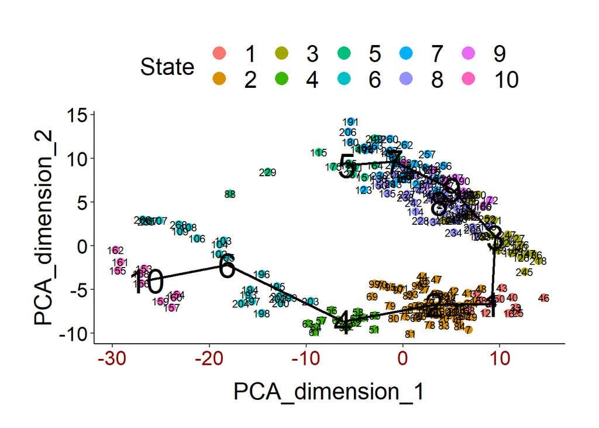

```r
set.seed(1)
# Preprocesamos la matriz de conteos crudos
procdeng <- TSCAN::preprocess(raw_deng)

# Cambiamos el nombre de las columnas de tipo celular a índice numérico
colnames(procdeng) <- 1:ncol(raw_deng)

# Hacemos el clustering con `mclust`
dengclust <- TSCAN::exprmclust(procdeng, clusternum = 10)

# Graficamos el resultado
TSCAN::plotmclust(dengclust)
```

```r
# Ordenamos las células. Con `orderonly = F`, nos devuelve también el
# pseudotiempo.
dengorderTSCAN <- TSCAN::TSCANorder(dengclust, orderonly = F)
pseudotime_order_tscan <- as.character(dengorderTSCAN$sample_name)

# Creamos el bolsillo vacío "pseudotime_order_tscan" en el objeto deng_SCE
deng_SCE$pseudotime_order_tscan <- NA
deng_SCE$pseudotime_order_tscan[as.numeric(dengorderTSCAN$sample_name)] <- dengorderTSCAN$Pseudotime
```

Ahora vemos los *timepoints* que se han asignado a cada estado celular:

```r
# El último cúster (nº10), o sea el último paso del pseudotiempo según TSCAN,
# corresponde a células en fase "late2cell"
cellLabels[dengclust$clusterid == 10]
```

```
##  [1] late2cell late2cell late2cell late2cell late2cell late2cell late2cell
##  [8] late2cell late2cell late2cell
## 10 Levels: zy early2cell mid2cell late2cell 4cell 8cell 16cell ... lateblast
```

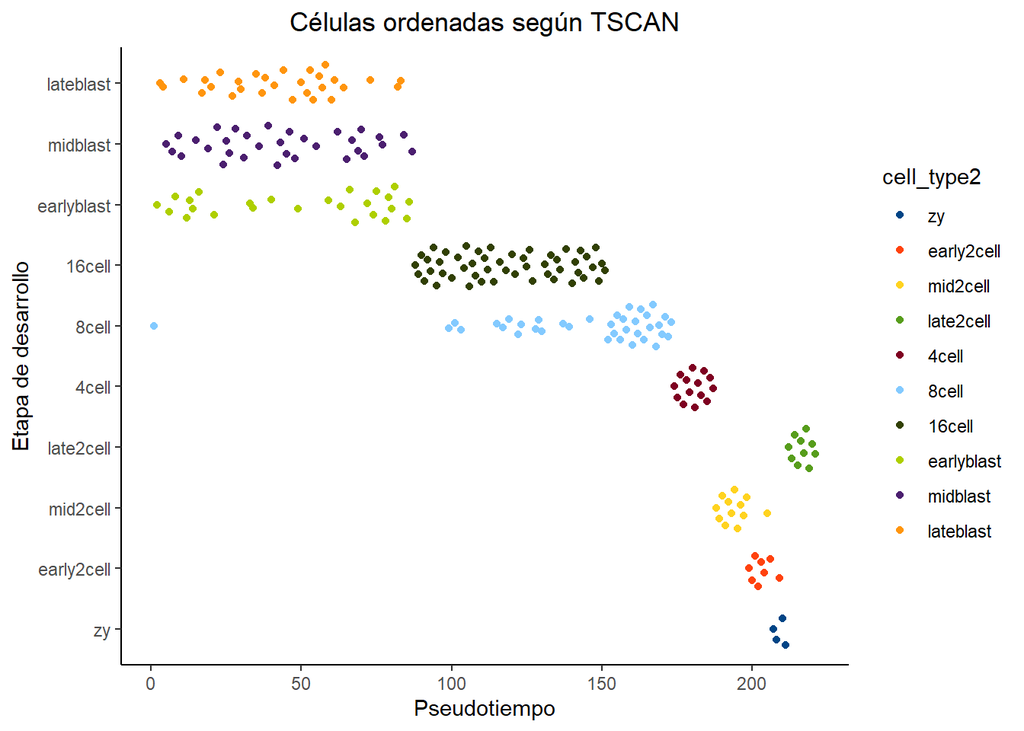

```r
# Graficamos el pseudotiempo final de TSCAN
ggplot(as.data.frame(colData(deng_SCE)),
       aes(x = pseudotime_order_tscan, y = cell_type2, colour = cell_type2)) +
       geom_quasirandom(groupOnX = F) + theme_classic() +
       theme(plot.title = element_text(hjust = 0.5)) +
       ggtitle("Células ordenadas según TSCAN") +
       xlab("Pseudotiempo") + ylab("Etapa de desarrollo") +
       scale_colour_calc()
```

En la gráfica se aprecia que en nuestro dataset, TSCAN infiere al revés la trayectoria del desarrollo embrionario. Esto no es un problema *per se* ya que podemos darle la vuelta al ordenamiento para entenderlo, pero no podemos asegurar que funcione mejor que el ordenamiento que hicimos mediante las coordenadas de la 1ª componente principal. El motivo de esto se debe al hecho de que TSCAN es un método de inferencia de trayectoria basado en PCA.

**Ejercicio 2.1: Compara los resultados obtenidos al variar el parámetro `clusternum` (nº de clusters) del comando `exprmclust`**

**Solución**: en este dataset, TSCAN infiere bien en su mayoría la trayectoria del desarrollo embrionario si elegimos `clusternum` entre 3 y 8.

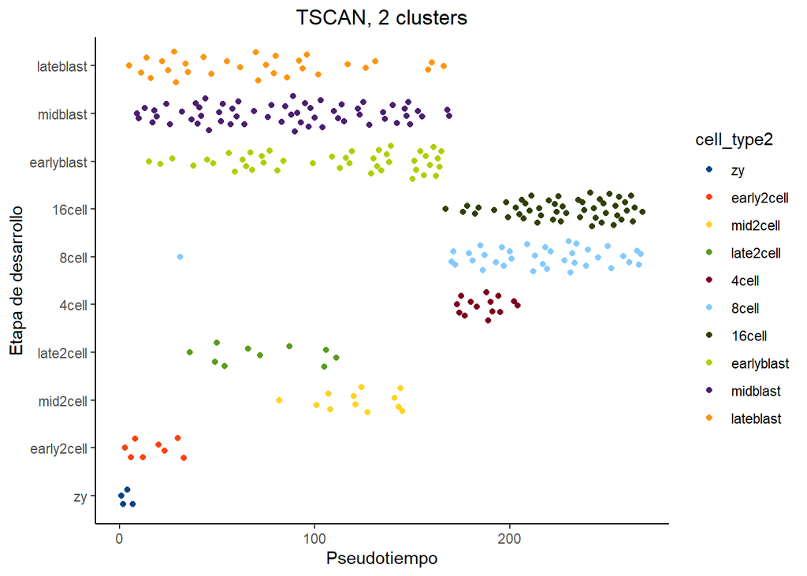

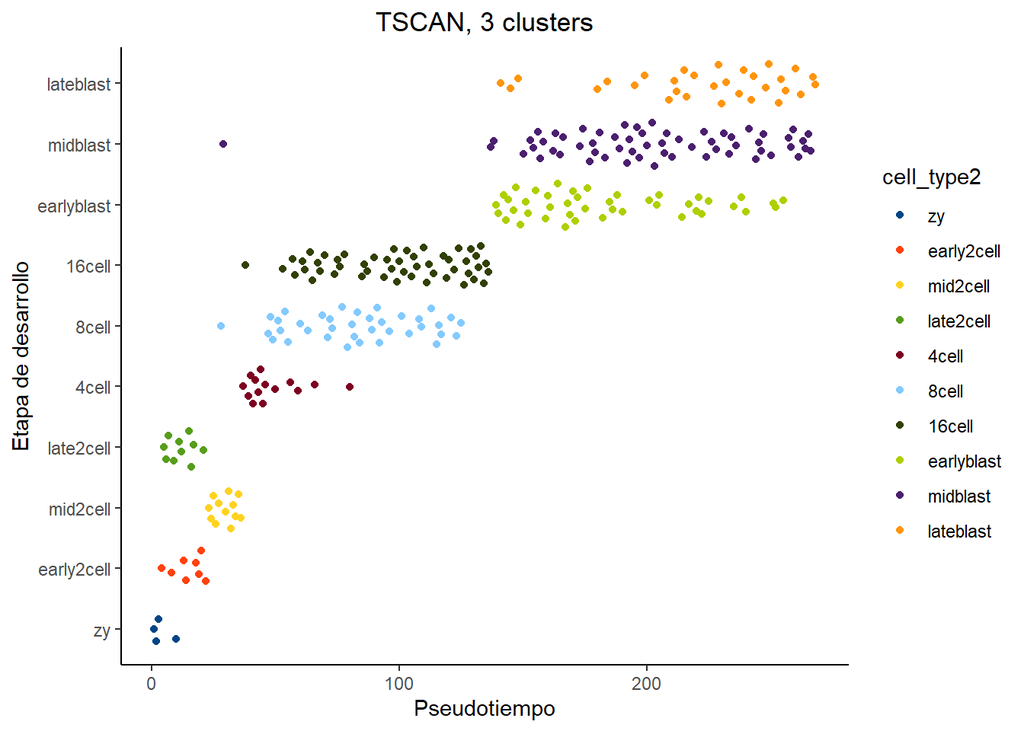

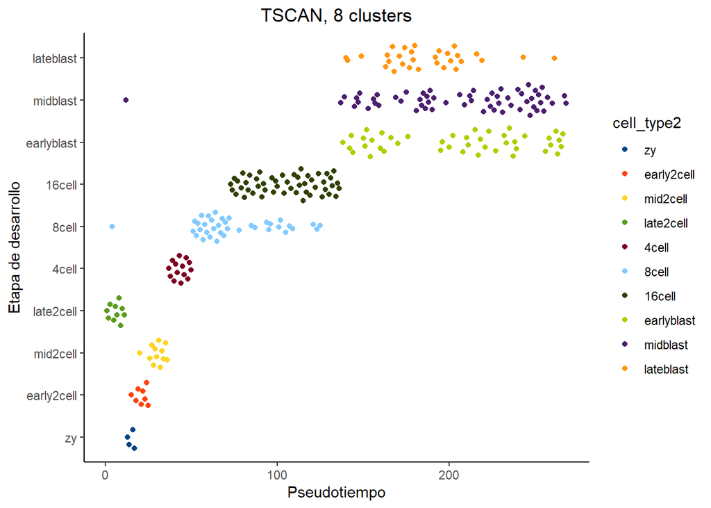

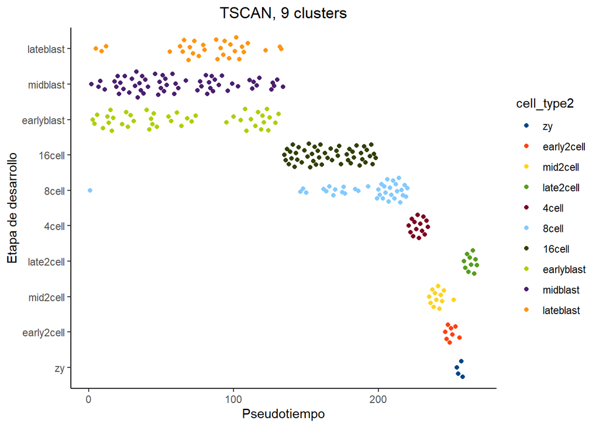

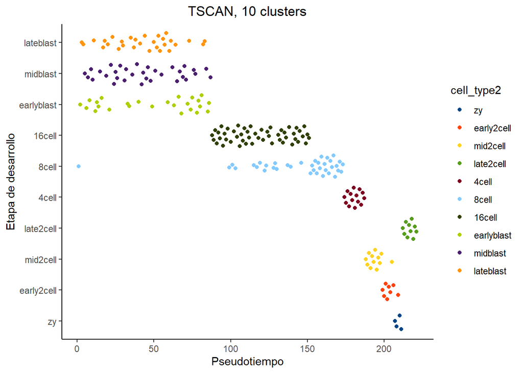

# 4 Mapas de difusión: `destiny`

Los mapas de difusión fueron inventados por Ronald Coifman y Stephane Lagon, y la idea principal es asumir que los datos son muestras de un proceso de difusión. Este método infiere la estructura de los datos en un espacio de baja dimensionalidad al estimar los *eigenvalues* y los *eigenvectors* (valores y vectores propios) del operador de la difusión relacionado con los datos.

Angerer *et al.* han aplicado el concepto de los mapas de difusión al análisis de datos scRNA-seq para crear así un paquete de R llamado `destiny`.

Si en la sección del PCA comentábamos que el pseudotiempo era las coordenadas de la 1ª componente principal, en `destiny` el pseudotiempo pasa a ser las coordenadas de la 1ª componente de difusión.

```r
set.seed(1)
# Primero creamos la matriz de conteos en forma logarítmica con `logcounts`.
# Recuerda que usa el "pseucocount of 1", o sea, log2(x+1), para definir el 0.
log_deng <- logcounts(deng_SCE)

# Ponemos bien los nombres de las células en la matriz de conteos en formato
# logarítmico
colnames(log_deng) <- cellLabels

# Calculamos las componentes de difusión. Hay que transponer la matriz de
# conteos logarítmicos. Por defecto, `DiffusionMap` usa como input el PCA, creo
dm <- DiffusionMap(t(log_deng))

# Creamos un dataframe _ad interim_ con 3 columnas: DC1, DC2 y etapa_desarrollo
tmp <- data.frame(DC1 = eigenvectors(dm)[,1],
                  DC2 = eigenvectors(dm)[,2],
                  etapa_desarrollo = cellLabels) # = deng_SCE$cell_type2
```

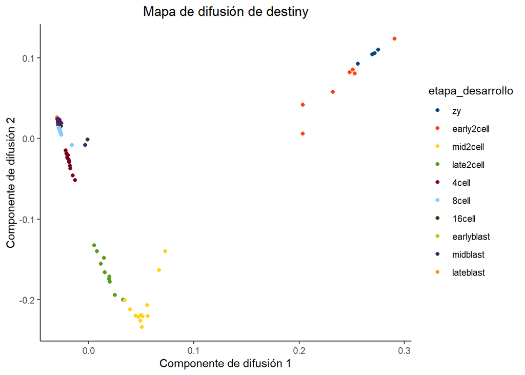

```r
# Graficamos las dos primeras componentes del mapa de difusión
ggplot(tmp, aes(x = DC1, y = DC2, color = etapa_desarrollo)) + geom_point() +
       theme_classic() + theme(plot.title = element_text(hjust = 0.5)) +
       xlab("Componente de difusión 1") + ylab("Componente de difusión 2") +
       scale_color_calc() + ggtitle("Mapa de difusión de destiny")
```

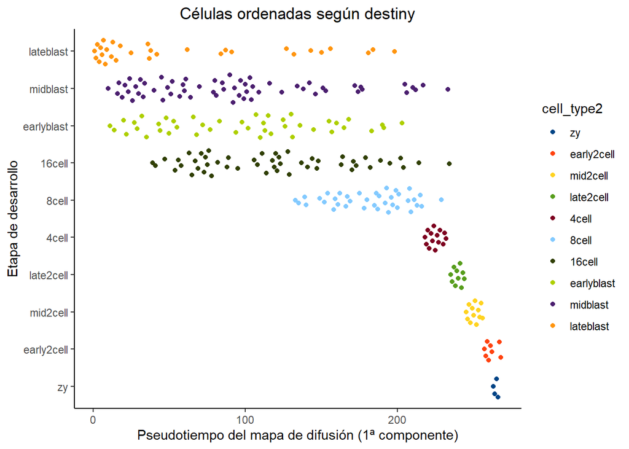

```r
# Ordenamos las células según sus coordenadas en la primera componente de
# difusión
deng_SCE$pseudotime_diffusionmap <- rank(eigenvectors(dm)[,1])

# Graficamos la trayectoria final inferida
ggplot(as.data.frame(colData(deng_SCE)), aes(x = pseudotime_diffusionmap, y = cell_type2, colour = cell_type2)) +
       geom_quasirandom(groupOnX = FALSE) + scale_color_calc() + theme_classic() +
       theme(plot.title = element_text(hjust = 0.5)) + xlab("Pseudotiempo del mapa de difusión (1ª componente)") +
       ylab("Etapa de desarrollo") + ggtitle("Células ordenadas según destiny")
```

Al igual que otros métodos, usar la 1ª componente de difusión a modo de pseudotiempo nos ayuda a ordenar las células tempranas, pero no puede distinguir las células en etapas más avanzadas del desarrollo (embrión con 8 o más células).

# 5 SLICER

SLICER es un algoritmo para construir trayectorias que describen cambios en la expresión génica durante un proceso biológico secuencial (al igual que `Monocle` y `TSCAN`). SLICER está diseñado para capturar cambios de expresión génica no lineales, seleccionar automáticamente aquellos genes que participen en el proceso biológico y detectar *branches*/caminos alternativos y *loops* en la trayectoria ([Welch *et al.*, 2016](https://genomebiology.biomedcentral.com/articles/10.1186/s13059-016-0975-3)). El paquete de SLICER está disponible en [GitHub](https://github.com/jw156605/SLICER) y se puede instalar mediante `devtools`.

Usamos la función `select_genes` de SLICER para seleccionar automáticamente los genes que se usarán para construir la trayectoria celular. La función usa la “neighbourhood variance” para identificar los genes que varían suavemente (en lugar de aquellos que fluctúan aleatoriamente) en las células estudiadas. A continuación, determinamos el nº de vecinos cercanos o *nearest neighbours* (parámetro `k`) que provee un *embedding* o embebimiento lo más parecido a una trayectoria. Finalmente estimamos el *embedding* local lineal (LLE) de las células.

```r
set.seed(1)
# Para seleccionar los genes en SLICER, usamos la matriz logarítmica traspuesta.
# Ídem para seleccionar k
slicer_genes <- select_genes(t(log_deng))
k <- select_k(t(log_deng[slicer_genes,]), kmin = 30, kmax = 60)
```

[output not shown]

```r
# La librería `lle` permite usar el comando homónimo para calcular el LLE o
# Locally Linear Embedding.
library("lle")
slicer_traj_lle <- lle(t(log_deng[slicer_genes,]), m = 2, k)$Y # Importante usar esta notación, si no, no funciona conn_knn_graph()
```

```
## finding neighbours
## calculating weights
## computing coordinates
```

```r
# Añadimos los resultados de la técnica de reducción de la dimensionalidad al
# objeto original deng_SCE
reducedDim(deng_SCE, type = "LLE") <- slicer_traj_lle
reducedDimNames(deng_SCE)
```

```
## [1] "PCA" "LLE"
```

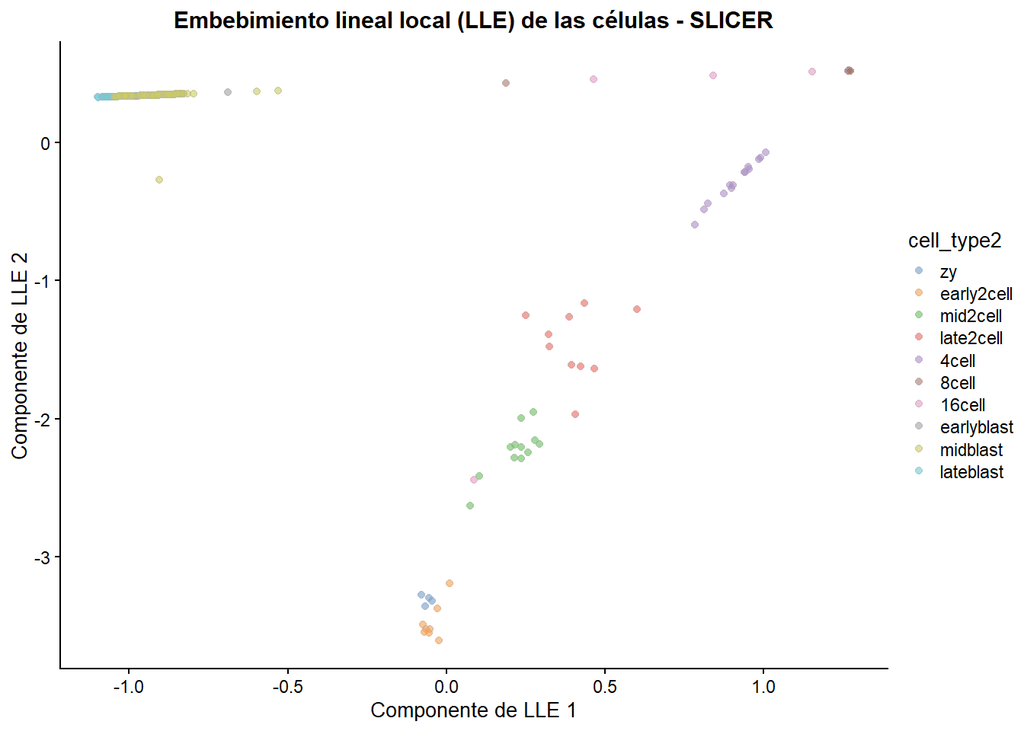

```r
# Graficamos el espacio de dimensionalidad reducida
plotReducedDim(deng_SCE, dimred = "LLE", colour_by = "cell_type2") +
                xlab("Componente de LLE 1") + ylab("Componente de LLE 2") +
                ggtitle("Embebimiento lineal local (LLE) de las células - SLICER") +
                theme(plot.title =  element_text(hjust = 0.5))
```

Ahora que hemos calculado el LLE, podemos construir un grafo basado en k-nearest neighbours (k-NN) que sea completamente conectado ( *fully connected*, como se suele decir en MLPs). Este gráfico muestra un círculo naranja por cada célula, con la ID de la célula representada en azul encima del círculo. Mostramos a continuación el grafo obtenido con k = 10 vecinos.

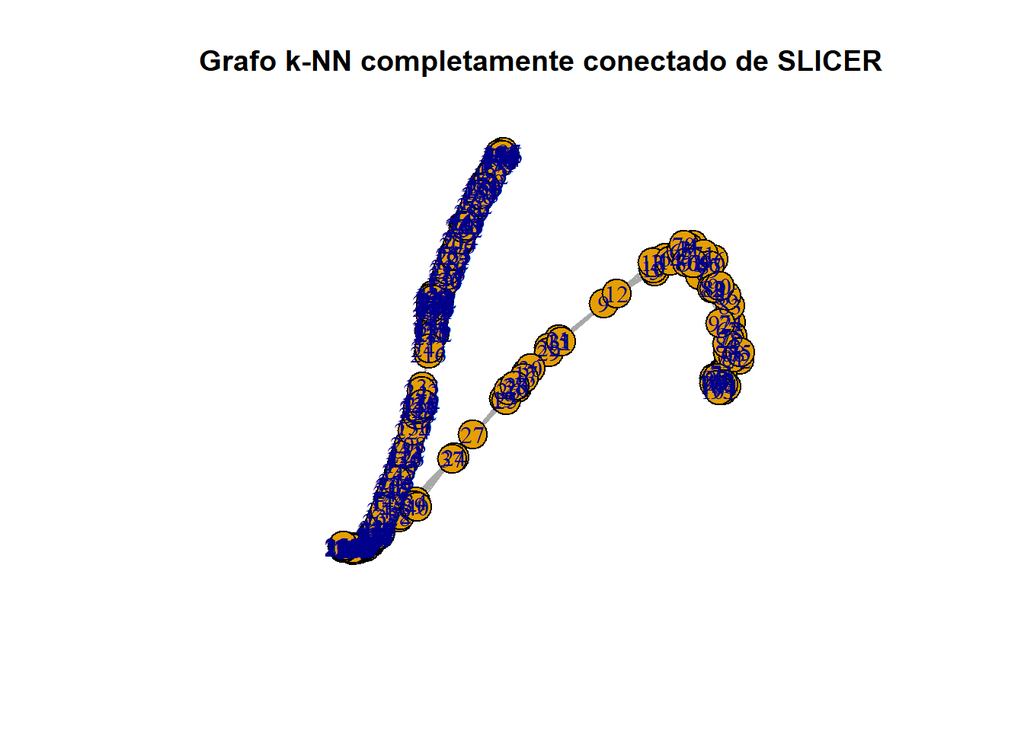

```r
# Construimos el grafo con la función `conn_knn_graph()`
slicer_traj_graph <- conn_knn_graph(slicer_traj_lle, k = 10)

# Graficamos
plot(slicer_traj_graph, main = "Grafo k-NN completamente conectado de SLICER")
```

A partir del grafo podemos identificar las células distales (de los extremos), las cuales serán candidatas para el comienzo y el fin de la trayectoria.

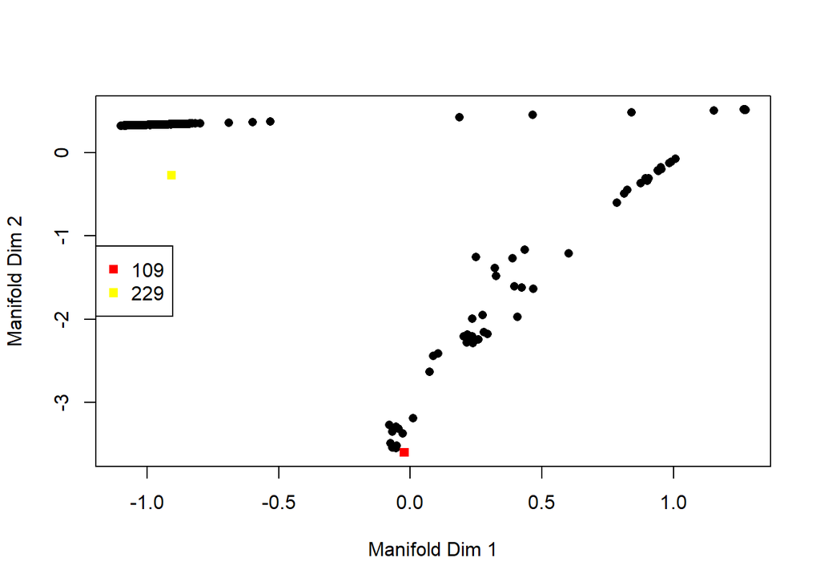

```r
# Encontramos células distales con el comando `find_extreme_cells()`
ends <- find_extreme_cells(traj_graph = slicer_traj_graph, embedding = slicer_traj_lle)
```

```r
start <- ends[1]
```

Tras definir la célula inicial, ordenamos las células a lo largo del pseudotiempo.

```r
# Ordenamos las células en el pseudotiempo con la función `cell_order()` del
# paquete SLICER
pseudotime_order_slicer <- cell_order(slicer_traj_graph, start)

# Detectamos ramas
branches <- assign_branches(slicer_traj_graph, start)

# creamos dataframe con las ramas, los estadios celulares y el pseudotiempo
pseudotime_slicer <- data.frame(TimePoint = cellLabels,
                                pseudotime = NA,
                                State = branches)

# Añadimos a la columna pseudotime del dataframe anterior el orden de las
# células en el pseudotiempo
pseudotime_slicer$pseudotime[pseudotime_order_slicer] <-  1:length(pseudotime_order_slicer)
```

Hecho esto, ahora podemos comparar el pseudotiempo inferido por SLICER con las etapas del desarrollo ya conocidas. SLICER no devuelve un pseudotiempo *per se*, sino simplemente el orden final de las células.

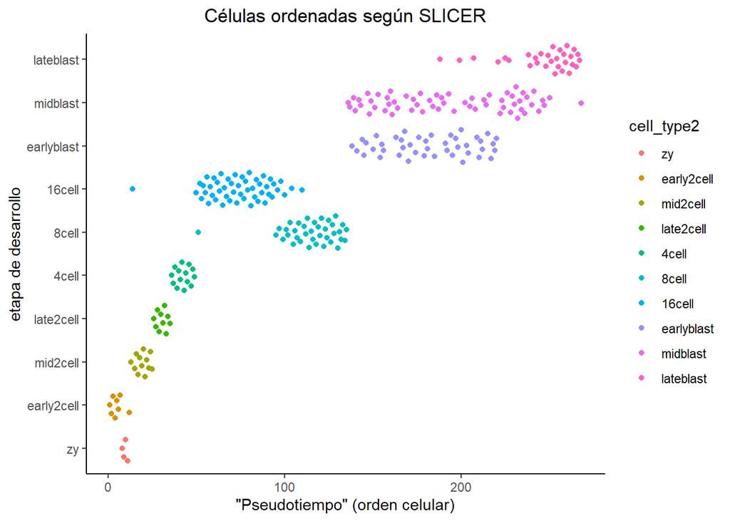

```r
# Añadimos al objeto `deng_SCE` el pseudotiempo del dataframe anterior para
# comparar los resultados con los métodos anteriores y la verdad experimental
deng_SCE$pseudotime_slicer <- pseudotime_slicer$pseudotime

# Graficamos el resultado
ggplot(as.data.frame(colData(deng_SCE)), aes(x = pseudotime_slicer, y = cell_type2, colour = cell_type2)) +
  geom_quasirandom(groupOnX = F) + xlab(" \"Pseudotiempo\" (orden celular) ") + ylab("etapa de desarrollo") +
  theme_classic() + ggtitle("Células ordenadas según SLICER") + theme(plot.title = element_text(hjust = 0.5))
```

Al igual que los métodos ya probados hasta ahora, SLICER ordena bien las primeras etapas de desarrollo, aunque ha invertido el orden de las etapas “16cell” y “8cell”. Pese a ello, logra separar un poco mejor las blastómeras tardías del resto de blastómeras.

**Ejercicio 2.2: ¿Cómo cambian los resultados del LLE en función del valor de `k`? ¿Y qué pasa al cambiar el nº de vecinos cercanos en la función `conn_knn_graph()`?**

**Solución**:

- Manteniendo el parámetro `k = 60` del LLE y variando el parámetro `k` del comando `conn_knn_graph()`, vemos que a mayor nº de vecinos cercanos, la trayectoria se perfila cada vez más, si bien el ordenamiento final de las células se mantiene igual. Nótese que para valores muy bajos de vecinos (k = 1~3), el comando `assign_branches` devuelve el error `Error in 1:num_branches : Argumento NA/NaN`
- Manteniendo el parámetro `k = 10` del grafo y variando el parámetro `k` del LLE, vemos que para valores extremos de `k`, a SLICER le cuesta ordenar las células. SLICER ordena exitosamente las células tempranas con un `k = 30`, mientras que con `k = 55` intenta separar las blastómeras (aunque sin mucho éxito). Nótese que para valores muy bajos de vecinos (k < 10), el comando `assign_branches` devuelve el error `Error in if (mean_dist < min_dist) { : valor ausente donde TRUE/FALSE es necesario` (Si se observa la función con F2, se aprecia que se omitieron algunos casos en la sección de condicionales).

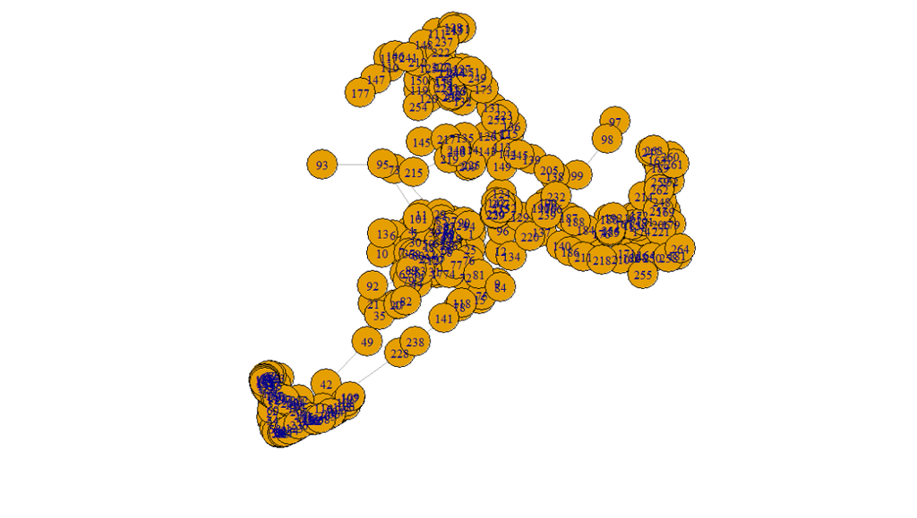

**Grafo con k = 1; LLE con k fijo en 60**

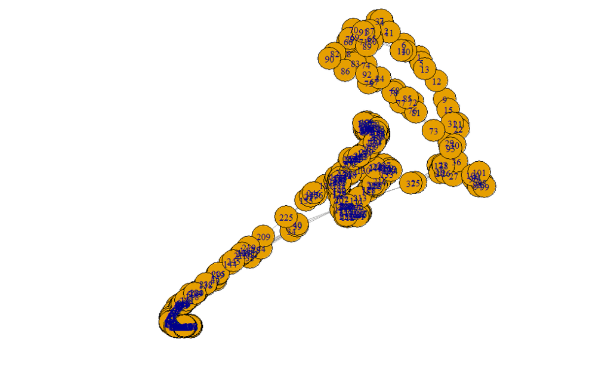

**Grafo con k = 5; LLE con k fijo en 60**

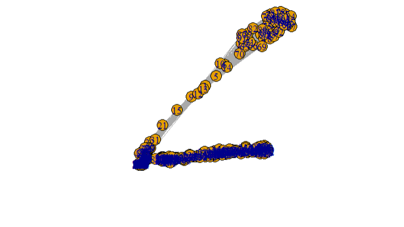

**Grafo con k = 30; LLE con k fijo en 60**

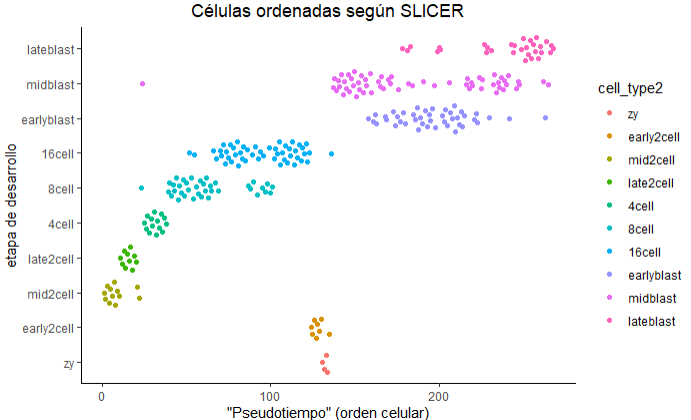

**Orden celular con LLE con k = 10; grafo con k fijo en 10**

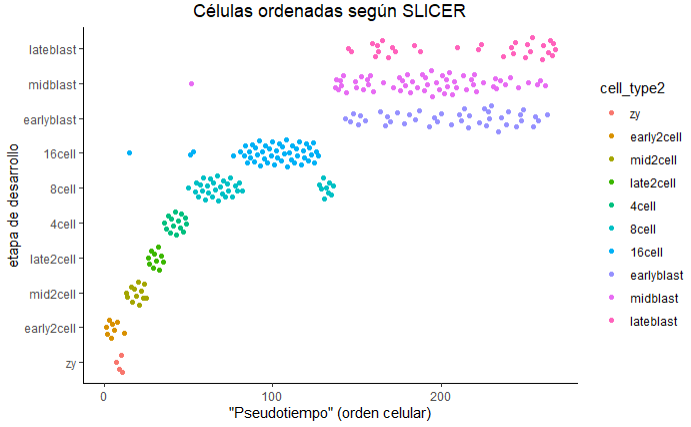

**Orden celular con LLE con k = 30; grafo con k fijo en 10**

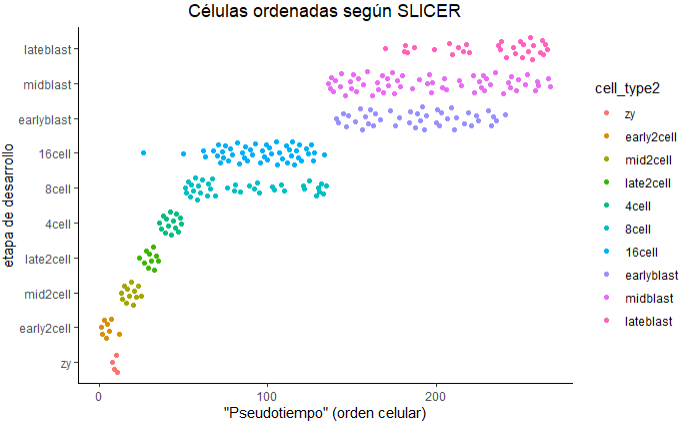

**Orden celular con LLE con k = 50; grafo con k fijo en 10**

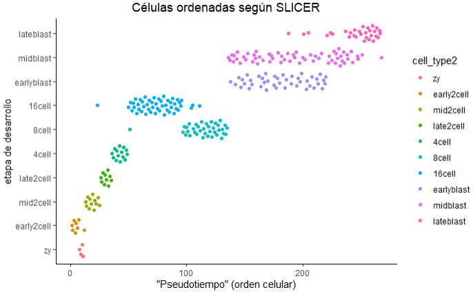

**Orden celular con LLE con k = 55; grafo con k fijo en 10**

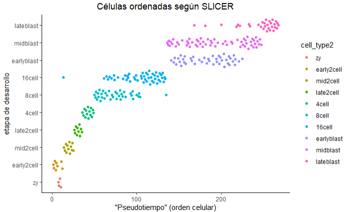

**Orden celular con LLE con k = 100; grafo con k fijo en 10**

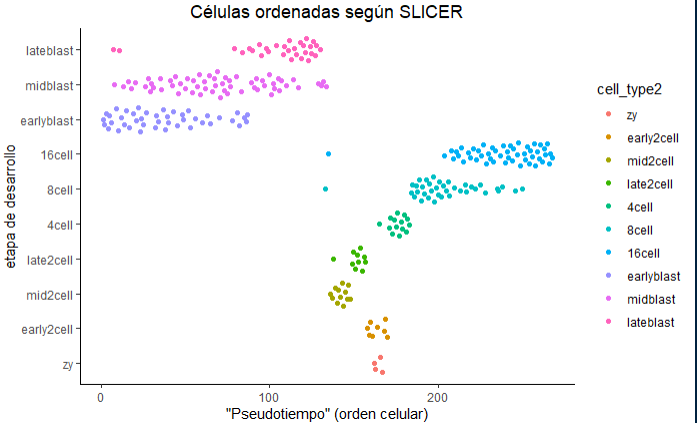

**Orden celular con LLE con k = 150; grafo con k fijo en 10**

# 6 ouija

`ouija` (viñeta online: http://kieranrcampbell.github.io/ouija/) infiere la trayectoria de manera distinta a como lo han hecho los paquetes previamente presentados. Mientras que `TSCAN`, `destiny` y `SLICER` eran métodos no supervisados y no tenían en cuenta las etiquetas asignadas por el investigador, `ouija` es un algoritmo probabilístico capaz de inferir el pseudotiempo a partir de un pequeño panel de genes marcadores. En concreto, este algoritmo:

- Infiere el pseudotiempo a partir de un nº reducido de biomarcadores, llevando la atención del investigador a dichos genes.
- Proporciona estimaciones de los parámetros (incluye incertidumbre), lo que permite interpretar patrones de regulación génica.
- Posee un test para hipótesis Bayesiana para encontrar a lo largo de la trayectoria genes regulados antes que otros.
- Identifica estados metaestables a lo largo de la trayectoria, *i.e.* tipos celulares discretos.

En `ouija` podemos modelar los genes de varias maneras:

- Que se sobre o infraexpresen de manera monotónica ( *i.e.* su expresión a lo largo del tiempo es exclusivamente al alza o a la baja, respectivamente). Esto se conoce como comportamiento *switch-like*.
- Que se sobre o infraexpresen de manera aguda ( *i.e.* la expresión del gen alcanza brevemente y de manera rápida un máximo/mínimo). Esto se conoce como comportamiento transitorio.

Por defecto, `ouija` asume que todos los genes usan el modelo monotónico, aunque el autor asegura que no pasa nada, pues modelar un gen transitorio como uno monotónico tiene un efecto mínimo en los resultados finales.

Proporcionaremos a `ouija` los siguientes biomarcadores (junto con la etapa del desarrollo en la que se sobreexpresan):

- Etapa inicial: Dazl, Rnf17, Sycp3, Nanog, Pou5f1, Fgf8, Egfr, Bmp5, Bmp15
- Etapa intermedia: Zscan4b, Foxa1, Prdm14, Sox21
- Etapa tardía: Creb3, Gpx4, Krt8, Elf5, Eomes, Cdx2, Tdgf1, Gdf3

En nuestro caso particular con el dataset de Deng podemos hacer un poco de trampas y comprobar que nuestros genes marcadores seleccionados son realmente biomarcadores de las distintas etapas del desarrollo aquí estudiadas.

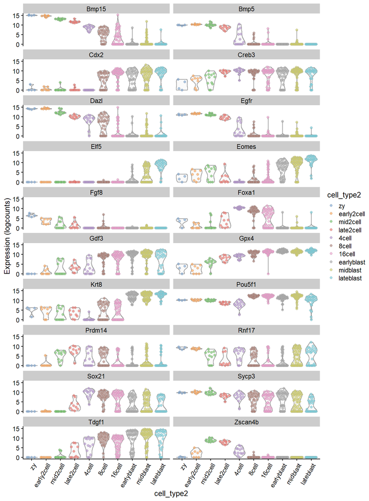

```r
ouija_markers_up <- c("Creb3", "Gpx4", "Krt8", "Elf5", "Eomes", "Cdx2", "Tdgf1", "Gdf3") # Son los genes de la etapa tardía

ouija_markers_down <- c("Dazl", "Rnf17", "Sycp3", "Pou5f1", "Fgf8", "Egfr", "Bmp5", "Bmp15") # Son los genes de la etapa inicial, excepto Nanog

ouija_markers_transient <- c("Zscan4b", "Foxa1", "Prdm14", "Sox21") # Son los genes de la etapa intermedia

ouija_markers <- c(ouija_markers_up, ouija_markers_down, ouija_markers_transient)

plotExpression(deng_SCE, features = ouija_markers, x = "cell_type2", colour_by = "cell_type2") +
  theme(axis.text.x = element_text(angle = 60, hjust = 1))
```

- Una matriz de célula(fila) x gen(columna) con valores de expresión génica no negativos.
- Una matriz de conteos logarítmica, producto de aplicar el comando `logcounts()` a un objeto de tipo `SingleCellExperiment`.
- Un objeto de tipo `ExpressionSet`.

Podemos añadir información conocida *a priori* respecto a la sobre o infraexpresión de los genes implicados en el proceso biológico estudiado, además de incluir conocimiento previo sobre el tipo de modelo que sigue cada gen (monotónico/transitorio).

Podemos contruir el modelo de `ouija` con:

- El método de Monte Carlo Hamiltoniano o Monte Carlo Híbrido ( *Hamiltonian Monte Carlo* o HMC). Consiste en inferencia completa con el método de Monte Carlo basado en Cadenas de Markov ( *Monte Carlo Markov Chain* o MCMC) en la cual se usa la información del gradiente de la *log-posterior* (logaritmo de la probabilidad *a posteriori*) para guiar el paseo aleatorio en el espacio del parámetro.
- El método de *Automatic Differentiation Variational Bayes*, ADVI o simplemente VI. Consiste en inferencia aproximada en la cual se minimiza la divergencia Kullback-Leibler o KL (una medida de distancia asimétrica y distinta de la euclídea; no es lo mismo medir la distancia *forwards KL* que la distancia *backwards KL*) a una distribución aproximada.

En general, el método de HMC infere de manera más precisa la trayectoria y devuelve una varianza posterior aproximadamente correcta para todos los parámetros. No obstante, el ADVI es *significativamente* más rápido que HMC y aunque pueda infraestimar la varianza *a posteriori*, el autor de `ouija` comenta que en ocasiones ADVI puede devolver resultados igual de buenos que los obtenidos con HMC, en cuanto a descubrimiento de pseudotiempos posteriores se refiere.

```r
# Tipo de respuesta de cada gen
response_type <- c(rep("switch", length(ouija_markers_down) + length(ouija_markers_up)),
                   rep("transient", length(ouija_markers_transient)))

# c(rep("switch", length(ouija_markers_down) + length(ouija_markers_up))) equivale a
# c(rep("switch", length(ouija_markers_down)), rep("switch, length(ouija_markers_up)))

# Certeza del comportamiento de nuestros biomarcadores
switch_strengths <- c(rep(-10, length(ouija_markers_down)),
                      rep(10, length(ouija_markers_up)))

# desviación estándar de dicha certeza
switch_strength_sd <- c(rep(0.5, length(ouija_markers_down)),
                         rep(0.5, length(ouija_markers_up)))


# El comando `ouija()` recomienda usar la siguiente línea de código para
# paralelizar en local su computación:
options(mc.cores = parallel::detectCores())

oui_vb <- ouija(x = deng_SCE[ouija_markers,],
                response_type = response_type,
                switch_strengths = switch_strengths,
                switch_strength_sd = switch_strength_sd,
                inference_type = "vb",
                single_cell_experiment_assay = "logcounts")
print(oui_vb)
```

```
## A Ouija fit with 268 cells and 20 marker genes
## Inference type:  Variational Bayes
## (Gene behaviour) Switch/transient: 16 / 4
```

We can plot the gene expression over pseudotime along with the maximum a posteriori (MAP) estimates of the mean function (the sigmoid or Gaussian transient function) using the `plot_expression()` function.

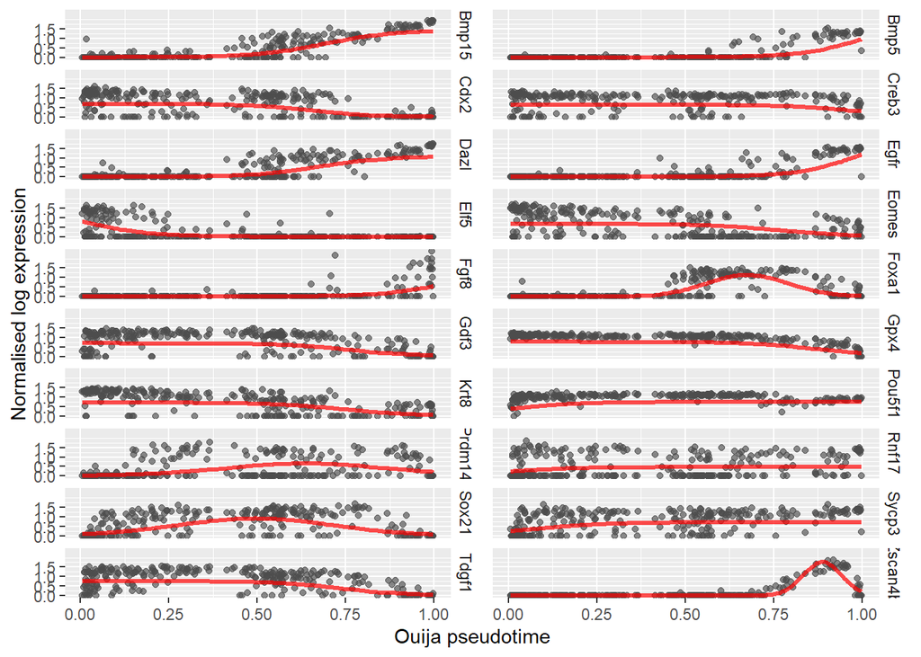

```r
plot_expression(oui_vb)
```

# 7 sessionInfo()